# final

Manik Mukherjee

```r
#import libraries to make the rest of the code work
library(DataComputing)
```

# Do county election results correlate to the percentage of the population that is not white?

### Data Access

The link to the third source is required to be linked to according to the download website: https://simplemaps.com/data/us-zips. The data below is importing the data into the R notebook. We then inspect the data by looking at the first 6 values of each of the sources and also looking at some of the variable names and types by using the str() function.

# Import the data

```r
primary <- read.csv(file = "countypres_2000-2016.csv")
secondary <- ZipDemography[, c("Totalpopulation", "White", "ZIP")]
third <- read.csv(file = "uszips.csv")[, c("zip", "county_name")]
```

# Inspect the data

```r
head(primary)
```

|  | year | state | state_po | county | FIPS | office | candidate | party | candidatevotes | totalvotes | version |
| --- | --- | --- | --- | --- | --- | --- | --- | --- | --- | --- | --- |
| 1 | 2000 | Alabama | AL | Autauga | 1001 | President | Al Gore | democrat | 4942 | 17208 | 20191203 |
| 2 | 2000 | Alabama | AL | Autauga | 1001 | President | George W. Bush | republican | 11993 | 17208 | 20191203 |
| 3 | 2000 | Alabama | AL | Autauga | 1001 | President | Ralph Nader | green | 160 | 17208 | 20191203 |
| 4 | 2000 | Alabama | AL | Autauga | 1001 | President | Other | NA | 113 | 17208 | 20191203 |
| 5 | 2000 | Alabama | AL | Baldwin | 1003 | President | Al Gore | democrat | 13997 | 56480 | 20191203 |
| 6 | 2000 | Alabama | AL | Baldwin | 1003 | President | George W. Bush | republican | 40872 | 56480 | 20191203 |

```r
str(primary)
```

```
'data.frame':   50524 obs. of  11 variables:
 $ year          : int  2000 2000 2000 2000 2000 2000 2000 2000 2000 2000 ...
 $ state         : Factor w/ 51 levels "Alabama","Alaska",..: 1 1 1 1 1 1 1 1 1 1 ...
 $ state_po      : Factor w/ 51 levels "AK","AL","AR",..: 2 2 2 2 2 2 2 2 2 2 ...
 $ county        : Factor w/ 1854 levels "Abbeville","Acadia",..: 79 79 79 79 86 86 86 86 97 97 ...
 $ FIPS          : int  1001 1001 1001 1001 1003 1003 1003 1003 1005 1005 ...
 $ office        : Factor w/ 1 level "President": 1 1 1 1 1 1 1 1 1 1 ...
 $ candidate     : Factor w/ 10 levels "Al Gore","Barack Obama",..: 1 4 10 9 1 4 10 9 1 4 ...
 $ party         : Factor w/ 3 levels "democrat","green",..: 1 3 2 NA 1 3 2 NA 1 3 ...
 $ candidatevotes: int  4942 11993 160 113 13997 40872 1033 578 5188 5096 ...
 $ totalvotes    : int  17208 17208 17208 17208 56480 56480 56480 56480 10395 10395 ...
 $ version       : int  20191203 20191203 20191203 20191203 20191203 20191203 20191203 20191203 20191203 20191203 ...
```

```r
head(secondary)
```

|  | Totalpopulation | White | ZIP |
| --- | --- | --- | --- |
| 1 | NA | NA | 00501 |
| 2 | NA | NA | 00544 |
| 3 | NA | NA | 00601 |
| 4 | NA | NA | 00602 |
| 5 | NA | NA | 00603 |
| 6 | NA | NA | 00604 |

```r
str(secondary)
```

```
'data.frame':   42741 obs. of  3 variables:
 $ Totalpopulation: num  NA NA NA NA NA NA NA NA NA NA ...
 $ White          : num  NA NA NA NA NA NA NA NA NA NA ...
 $ ZIP            : chr  "00501" "00544" "00601" "00602" ...
```

```r
head(third)
```

|  | zip | county_name |
| --- | --- | --- |
| 1 | 601 | Adjuntas |
| 2 | 602 | Aguada |
| 3 | 603 | Aguadilla |
| 4 | 606 | Maricao |
| 5 | 610 | Añasco |
| 6 | 612 | Arecibo |

```r
str(third)
```

```
'data.frame':   33099 obs. of  2 variables:
 $ zip        : int  601 602 603 606 610 612 616 617 622 623 ...
 $ county_name: Factor w/ 1906 levels "Abbeville","Acadia",..: 8 9 10 1062 42 62 62 108 248 248 ...
```

# General Data Wrangling

```r
# find the total number of votes for democrats ever
democrat <- primary %>%
  filter(party == "democrat") %>%
  summarize(total_democrats = sum(totalvotes))
democrat
```

| total_democrats |
| --- |
| 624770866 |

```r
# find the total number of votes for republicans
republican <- primary %>%
  filter(party == "republican") %>%
  summarize(total_republicans = sum(totalvotes))
republican
```

| total_republicans |
| --- |
| 624770866 |

# Join Operation

```r
third[, "county_name"] <- as.character(third[, "county_name"])
primary[, "county"] <- as.character(primary[, "county"])
secondary[, "ZIP"] <- as.numeric(secondary[, "ZIP"])
names(secondary)[3] <- "zip"
names(third)[2] <- "county"
```

This combined table is joining together the primary and secondary datasets so we can see the white population and total population combined with the voting outcome for each county, which is integral to see the relationship between the voting outcome and the percentage of population that is white.

```r
combined <- left_join(secondary, third)
combined <- left_join(primary, combined)
head(combined)
```

|  | year | state | state_po | county | FIPS | office | candidate | party | candidatevotes | totalvotes | version | Totalpopulation | White | zip |
| --- | --- | --- | --- | --- | --- | --- | --- | --- | --- | --- | --- | --- | --- | --- |
| 1 | 2000 | Alabama | AL | Autauga | 1001 | President | Al Gore | democrat | 4942 | 17208 | 20191203 | 1794 | 681 | 36003 |
| 2 | 2000 | Alabama | AL | Autauga | 1001 | President | Al Gore | democrat | 4942 | 17208 | 20191203 | 1153 | 995 | 36006 |
| 3 | 2000 | Alabama | AL | Autauga | 1001 | President | Al Gore | democrat | 4942 | 17208 | 20191203 | 2015 | 1522 | 36051 |
| 4 | 2000 | Alabama | AL | Autauga | 1001 | President | Al Gore | democrat | 4942 | 17208 | 20191203 | 12499 | 11180 | 36066 |
| 5 | 2000 | Alabama | AL | Autauga | 1001 | President | Al Gore | democrat | 4942 | 17208 | 20191203 | 23177 | 17966 | 36067 |
| 6 | 2000 | Alabama | AL | Autauga | 1001 | President | Al Gore | democrat | 4942 | 17208 | 20191203 | 3185 | 2738 | 36091 |

# Regular Expressions

This regular expression extracts the last name (if applicable) from the candidate name, as many people refer to presidents by just their last name.

```r
last_names <- primary %>%
  select(candidate) %>%
  extractMatches("([^ ]+$)", candidate)
head(last_names)
```

|  | candidate | match1 |
| --- | --- | --- |
| 1 | Al Gore | Gore |
| 2 | George W. Bush | Bush |
| 3 | Ralph Nader | Nader |
| 4 | Other | Other |
| 5 | Al Gore | Gore |
| 6 | George W. Bush | Bush |

This filters counties that have “son”, “ger”, or “gua” in their name so that only those counties appear in the table.

```r
patterns <- third %>%
  filter(grepl("son|ger|gua", county, ignore.case = TRUE))
head(patterns)
```

|  | zip | county |
| --- | --- | --- |
| 1 | 602 | Aguada |
| 2 | 603 | Aguadilla |
| 3 | 656 | Guayanilla |
| 4 | 683 | San Germán |
| 5 | 690 | Aguadilla |
| 6 | 703 | Aguas Buenas |

# User Defined Functions

this function will print popular if the input over 10,000 votes and not popular if the input is not. This could be used in the context of votes to see if the candidate is popular or not within the county. Even though that candidate may not have won, they could still be popular.

```r
popular <- function(votes) {
  if (votes > 10000) {
    status <- "popular"
  } else {
      status <- "not popular"
    }
  status
}
```

this function will generate a random sample of size n from any dataset so so long as the sample size isn’t greater than the size of the dataset. This is useful for machine learning with large datasets, as the algorithm may not be able to handle the whole dataset at one time.

```r
random_sample <- function(dataset, n) {
  total <- 1:nrow(dataset)
  random <- sample(total, size = n, replace = FALSE)
  dataset[random, ]
}
random_sample(primary, 10)
```

|  | year | state | state_po | county | FIPS | office | candidate | party | candidatevotes | totalvotes | version |
| --- | --- | --- | --- | --- | --- | --- | --- | --- | --- | --- | --- |
| 26722 | 2008 | Nebraska | NE | Butler | 31023 | President | John McCain | republican | 2557 | 3839 | 20191203 |
| 18512 | 2004 | Ohio | OH | Allen | 39003 | President | Other | NA | 206 | 49274 | 20191203 |
| 39966 | 2012 | Washington | WA | Douglas | 53017 | President | Barack Obama | democrat | 5166 | 14942 | 20191203 |
| 31271 | 2012 | Alabama | AL | Houston | 1069 | President | Other | NA | 281 | 41918 | 20191203 |
| 45694 | 2016 | Nevada | NV | Lincoln | 32017 | President | Donald Trump | republican | 1671 | 2132 | 20191203 |
| 13532 | 2004 | Florida | FL | Wakulla | 12129 | President | Other | NA | 90 | 11763 | 20191203 |
| 44764 | 2016 | Mississippi | MS | Madison | 28089 | President | Donald Trump | republican | 28265 | 49802 | 20191203 |
| 38142 | 2012 | South Carolina | SC | Pickens | 45077 | President | Barack Obama | democrat | 11156 | 45549 | 20191203 |
| 24735 | 2008 | Kentucky | KY | Boyle | 21021 | President | Barack Obama | democrat | 4769 | 12635 | 20191203 |
| 21517 | 2004 | West Virginia | WV | Wood | 54107 | President | George W. Bush | republican | 24948 | 39227 | 20191203 |

# Loops or Control Flow

This while loop finds the amount of rows in the primary dataset that are in Alabama until it moves on to another state (there are more rows in the state of Alabama later).

```r
row <- 1
while (primary[row, "state"] == "Alabama") {
  row <- row + 1
}
row
```

```
[1] 269
```

```r
n <- 0
for (x in 1:nrow(primary)) {
  if (primary[x, "candidate"] == "Other") {
    n <- n + 1
  }
}
n
```

```
[1] 15789
```

### Data Visualization

This is data wrangling for the next plot. All of the following plots are for the year 2000.

```r
winner <- primary %>%
  filter(year == 2000) %>%
  distinct(state, county, party, candidatevotes) %>%
  group_by(state, county) %>%
  filter(candidatevotes == max(candidatevotes))
white_prop <- combined %>%
  filter(year == 2000) %>%
  group_by(state, county) %>%
  summarise(Totalpopulation = sum(Totalpopulation, na.rm = TRUE), White = sum(White, na.rm = TRUE))
winner_white <- left_join(winner, white_prop, by = c("state","county")) %>%
  mutate(prop = White/Totalpopulation) %>%
  group_by(party, prop=cut(prop, breaks= seq(0, 1, by = 0.1))) %>%
  summarise(n= n())
```

```
Factor `prop` contains implicit NA, consider using `forcats::fct_explicit_na`
```

```r
winner_white
```

| party | prop | n |
| --- | --- | --- |
| democrat | (0.1,0.2] | 2 |
| democrat | (0.2,0.3] | 13 |
| democrat | (0.3,0.4] | 22 |
| democrat | (0.4,0.5] | 27 |
| democrat | (0.5,0.6] | 39 |
| democrat | (0.6,0.7] | 51 |
| democrat | (0.7,0.8] | 107 |
| democrat | (0.8,0.9] | 165 |
| democrat | (0.9,1] | 155 |
| democrat | NA | 45 |

[output cut: 8 more lines]

This shows a bar plot of the the the number of counties that chose a specific party versus the percentage of white people living in that county. As seen in the plot, republicans mostly won in counties that were mostly white while democrats had more of an advantage in non-white dominated counties.

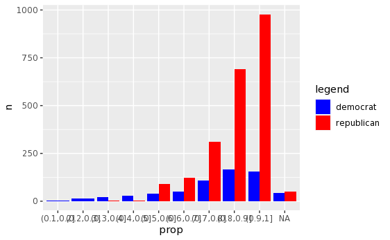

```r
ggplot(data=winner_white,aes(x=prop,y=n ,fill=party)) + geom_bar(stat='identity',position='dodge', width=.9) +
  scale_fill_manual("legend", values = c("democrat" = "blue", "republican" = "red"))
```

```r
percentages <- left_join(winner, white_prop, by = c("state", "county")) %>%
  mutate(prop = White/Totalpopulation) %>%
  group_by(party, prop=cut(prop, breaks= seq(0, 1, by = 0.1))) %>%
  summarise(n= n()) %>%
  group_by(prop) %>%
  mutate(percent = n/sum(n))
```

```
Factor `prop` contains implicit NA, consider using `forcats::fct_explicit_na`Factor `prop` contains implicit NA, consider using `forcats::fct_explicit_na`Factor `prop` contains implicit NA, consider using `forcats::fct_explicit_na`
```

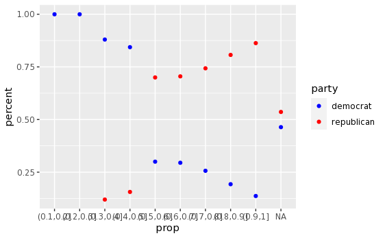

```r
ggplot(data=percentages,aes(x=prop,y=percent)) +
  geom_point(aes(color=party)) +
  scale_color_manual(values=c('#0000FF','#FF0000'))
```

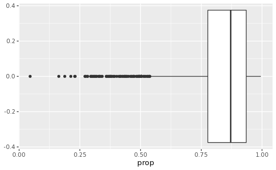

```r
white_prop <- white_prop %>%
  mutate(prop = White/Totalpopulation)

ggplot(white_prop, aes(x=prop)) +
  geom_boxplot()
```

This is a decision tree to predict the party that would win for each county, given the percentage of white people in that county and given the total population, and the amount of votes.

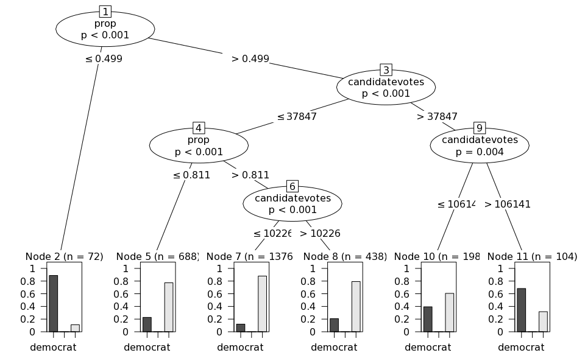

```r
library(party)
combined2 <- left_join(winner, white_prop, by = c("state","county")) %>%
  mutate(prop = White/Totalpopulation)
winner_predict <- ctree(party ~ prop + candidatevotes + Totalpopulation, data = combined2)
plot(winner_predict)
```